# Análisis COVID-19 Oaxaca

Juan Pablo Díaz Martínez

2020-06-10

# Introducción y antecedentes

Los coronavirus (Arabi, Murthy, and Webb 2020) son una familia de virus que suelen causar enfermedades en animales, aunque algunos pueden afectar también a humanos. En las personas pueden producir infecciones respiratorias que pueden ir desde un resfriado común hasta enfermedades más graves. En el 80% de los casos, la infección por este nuevo coronavirus, denominado oficialmente SARS-Cov-2, produce síntomas respiratorios de carácter leve. Con el nombre de COVID-19 se denomina la enfermedad respiratoria producida por este virus. Hasta el día de hoy (Jun 9) se han confirmado en nuestro país 124,301 casos y 14,649 muertes. Para el estado de Oaxaca, se han confirmado 2,363 casos y 250 muertes.

Mucho se ha hablado de la importancia de las medidas de mitigación para tratar de frenar la epidemia y así evitar la saturación de los hositales, especialmente aquellos de tercer nivel. La razón detrás de implementar estas medidas es el número básico de reproducción $R_0$, el cual mide en promedio cuantas personas son infectadas por una persona con la infección en una población susceptible. Una consecuencia de lo anterior es que en medida en que más personas se infecten, el número de reproducción disminuirá ya que en algún punto en el futuro se lograría la inmunidad de rebaño; a causa de esta temporalidad se introduce el número de efectivo de reproducción $R_t$ (Nishiura and Chowell 2009), teniendo la misma definición que $R_0$ pero ahora a tiempo $t$.

En nuestro país, tanto los gobiernos estatales como el gobierno federal han implementado diferentes medidas de mitigación con el objetivo de disminuir $R_t$, ya que al hacerlo resultaría en un número menor de infectados por SARS-Cov-2 y en consecuencia un número menor de hospitalizaciones y muertes. Si $R_t<1$ entonces se podría afirmar que la transmisión está bajo control y por lo tanto se podrían retirar una o varias medidas de mitigación.

## Vigilancia epidemiológica en México

La vigilancia epidemiológica en nuestro país se basa en un sistema centinela a través del sistema de Unidades de Salud Monitoras de Enfermedades Respiratorias (USMER), adoptado desde el año 2006. El objetivo de las unidades es brindar información epidemiológica de varios virus (e.g. influenza) de forma oportuna y completa, sin olvidar que éste no tiene como objetivo recopilar los casos completos en el país sino privilegiar la calidad de la información recopilada en estas unidades (OMS 2014). El 28 de febrero se confirmó el primer individuo con CoVID-19 en nuestro país, desde entonces se ha actualizado la definición operacional (siendo el 23 de marzo la última actualización) para casos sospechosos y casos confirmados:

- Caso sospechoso - Persona de cualquier edad que en los últimos siete días haya presentado al menos dos síntomas de tos, fiebre o cefalea, es decir, dolor de cabeza intenso y persistente y que esté acompañado de los siguientes signos: dificultad para respirar, hinchazón en articulaciones con dificultad de movimiento, dolor muscular, ardor de garganta, rinorrea, conjuntivitis y dolor de tórax.
- Caso confirmado - Persona que cumpla lo anterior y que cuente con confirmación del InDRE.

Asimismo, se modificó el porcentaje de muestreo para vigilar los casos de COVID-19. Solo se realizará la prueba al 10% de los casos sospechosos sin síntomas o síntomas leves. A su vez, se realizará la prueba al 100% de los casos sospechosos con sintomatología grave o que cumplan con la definición infección respiratoria aguda grave (IRAG).

## Características de los pacientes graves con COVID-19

Se estima que aproximadamente un 5% de los casos confirmados por cOVID-19 requerirán de cuidados intensivos (Murthy, Gomersall, and Fowler 2020). Lo anterior ha mostrado que ciertos países en el mundo experimentaran un rápido incremento en la utilización de recursos sanitarios, sobre todo aquellos países con una proporción importante de adultos mayores de 65 años (Remuzzi and Remuzzi 2020). Si bien es cierto que en nuestro país solamente el 7.25% de la población pertenece a este grupo de edad (OCDE), la evidencia en otros países ha revelado que la obesidad y sus comorbilidades asociadas son un factor de riesgo importante para aquellas personas menores de 60 años (Lighter et al. 2020). Lighter et al. encontraron que (2020) aquellos pacientes menores a 60 años con índice de masa corporal (IMC) de entre 30 y 34 que ingresaron a urgencias por COVID-19 tuvieron 1.8 más posibilidades de ingresar a terapia intensiva en comparación con aquellos pacientes sin obesidad (IMC<30); estas posibilidades aumentaron a 3.6 en aquellos pacientes con un IMC mayor o igual a 35.

De acuerdo a la más reciente Encuesta Nacional de Nutrición (ENSANUT 2018) realizada conjuntamente entre el Instituto Nacional de Salud Pública (INSP) y el Instituto Nacional de Estadística y Geografía (INEGI), aproximadamente 15.2 millones de mexicanos tienen diagnóstico previo de hipertensión mientras que el 75.2% de la población mayor a 2 años tiene obesidad y sobrepeso (Romero-Martı́nez et al. 2019). Asimismo la Secretaria de Salud ha reportado en sus informes técnicos diarios que los 3 principales grupos en riesgo de presentar complicaciones por COVID-19 son: personas mayores a 65 años, personas con Diabetes Mellitus (diagnosticada y no diagnosticada) y personas con hipertensión arterial.

Lo anterior se ha visto reflejado en las muertes de pacientes confirmados con COVID-19 en México (México 2020a); hasta el 20 de abril del presente año se habían presentado 686 defunciones, siendo hipertensión, diabetes y obesidad las comorbilidades más asociadas con las defunciones (43.1%, 38.3% y 31.4% respectivamente). Debido a la epidemia de enfermedades no transmisibles que existe en nuestro país desde hace tiempo, es posible que México experimente un número alto de defunciones debido a los factores antes mencionados ya que aumentan el riesgo de complicar esta enfermedad.

## Modelo Bayesiano semi-mecanístico

Muchos de los modelos epidemiológicos se basan en la incidencia de **casos confirmados** para poder hacer estimaciones y/o proyecciones de diferentes desenlaces en salud, ya sea mortalidad, hospitalizaciones, intubaciones, etc. Una de las grandes limitaciones es el tiempo que pasa entre el momento de la infección y el momento que la prueba resulta positiva. Esto se debe a que entre estos dos momentos hay un periodo de incubación (mediana 6 días (Lauer et al. 2020)) y un periodo entre que se toma la prueba y se entrega el resultado de ésta (mediana 9 días (México 2020b)). Una consecuencia de esto es que los casos confirmados que se presentan día a día son en realidad los casos que se infectaron hace 2 semanas o más. Adicionalmente, el sistema de vigilancia centinela no realiza pruebas a aquellos que no cumplen la definición operacional, implicando que este sistema no logra capturar a todas las personas asintomáticas. Esto pudiera generar diferentes brotes ya que existe evidencia científica relacionada a la transmisión del virus por parte de los que no presentan ningún tipo de síntoma (Bai et al. 2020). Debido a estas limitaciones, diferentes investigadores en enfermedades infecciosas han utilizado las muertes observadas como la variable principal para hacer inferencia en diferentes modelos epidemiológicos ((Flaxman et al. 2020)).

Por lo tanto, proponemos estimar el impacto que han tenido las medidas de mitigación en el número diario de infecciones por SARS-Cov-2, en el número de pacientes que requieran terapia intensiva y finalmente en el número de muertes, utilizando las **muertes diarias** como la variable observable para entrenar nuestro modelo. Utilizaremos un modelo jerárquico Bayesiano semi-mecanístico[^1] (Staff 2019) debido a la dependencia que existe entre los parámetros. Una ventaja de este tipo de modelos semi-mecanísticos es que los parámetros a estimar están influenciados por la variable observable y por lo tanto ésta representa un peso importante al momento de realizar la inferencia.

# Resultados

La siguiente gráfica muestra el número de casos confirmados acumulados con COVID-19 desde que se confirmó el paciente número 100. Se transformó el eje de las $y$ al aplicarle el logaritmo base 2; esta transformación ayuda a una mejor interpretación de los datos ya que es más fácil para el lector ver cuanto tiempo se tarda una región en tener el doble de casos confirmados en un periodo determinado de tiempo. Asimismo al transformar los datos la serie de tiempo presenta un comportamiento más lineal.

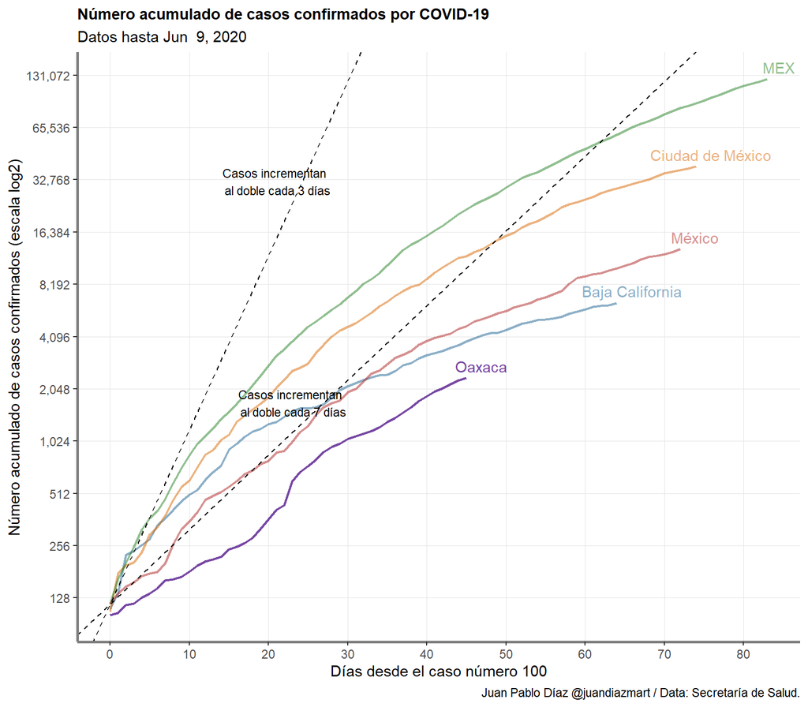

Asimismo, la siguiente gráfica nos ayuda a entender el comportamiento de número de muertes acumuladas en nuestro país desde que se presentó la quinta defunción.

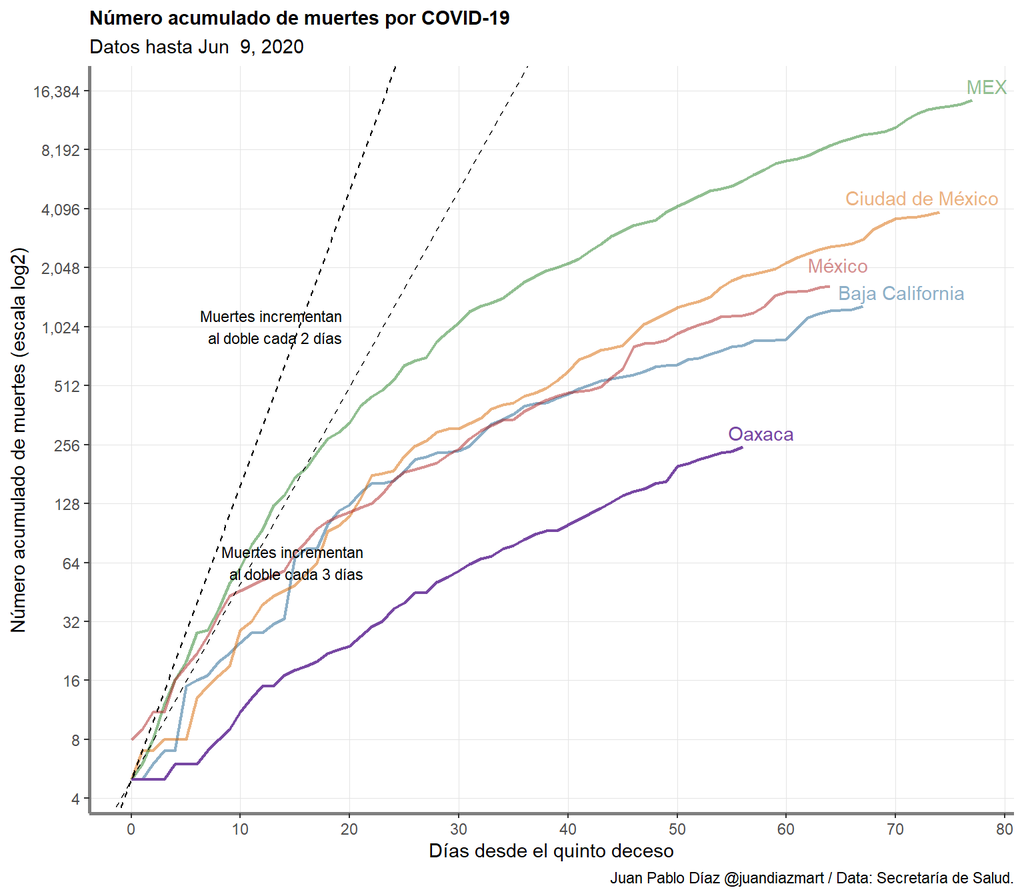

Utilizando los datos de muertes observadas que reporta la Secretaría de Salud a las 7 pm, presentamos a continuación los resultados del modelo Bayesiano para el estado de Oaxaca. Asimismo utilizamos el modelo publicado previamente (Flaxman et al. 2020). Programamos el modelo con `R` y `Stan` y nuestro interés es seguir usando código libre, abierto y reproducible.

El modelo estima que para Jun 9, el número acumulado de infectados por SARS-COV2 en Oaxaca es de 54,517 (95% CrI: 19,557 - 147,071) (ver Figura 1). Lo anterior representa al 1.36% (95% CrI: 0.49% - 3.68%) de la población total en Oaxaca, utilizando los datos de CONAPO para 2020 (4.1 millones aproximadamente).

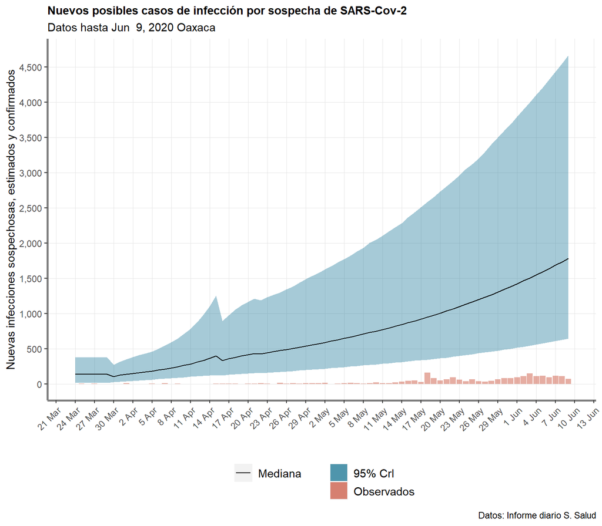

Figure 1: Nuevas posibles infecciones por SARS-Cov-2. La región azul representa la incertidumbre de nuesta estimación (línea negra). El histograma representa los casos confirmados reportados diariamente por la S. Salud

Al inicio de la epidemia en México, el número efectivo de reproducción $R_t$ (ver Figura 2) era de 1.6 (95% CrI: 1.2 - 3.0). Después de que el gobierno implementó el uso obligatorio de cubrebocas el 21 de abril, éste descendió a 1.2 (95% CrI: 1.1 - 1.3).

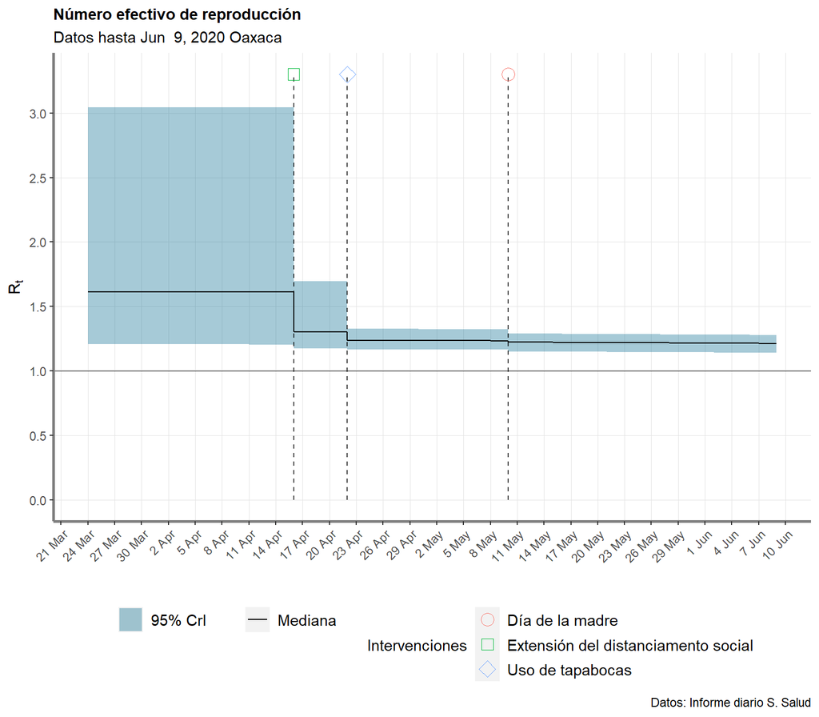

Figure 2: Impacto de las medidas de mitigación en el número efectivo de reproducción.

Adicionalmente, la siguiente gráfica muestra las nuevas hospitalizaciones desde que inicio la epidemia en el estado de Oaxaca.

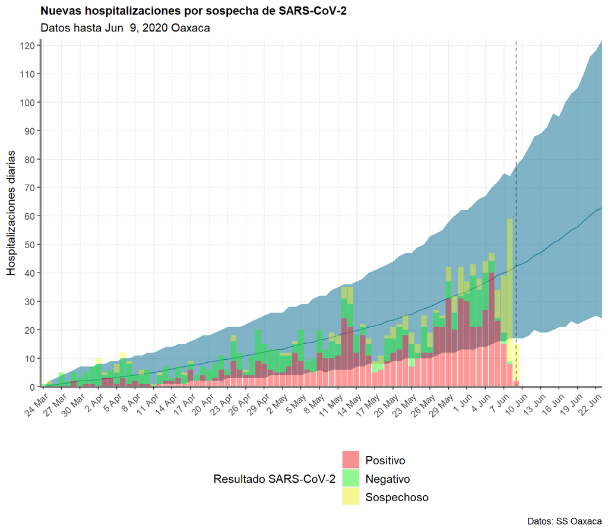

Figure 3: Nuevas hospitalizaciones por sospecha de COVID-19, observados y predichos.

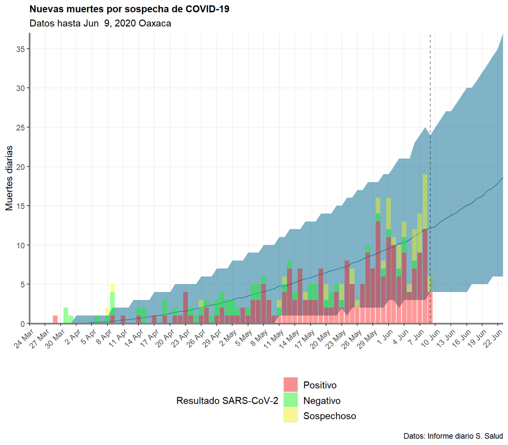

Figure 4: Nuevas muertes por sospecha de COVID-19, observados y predichos.

# Bibliografía

Arabi, Yaseen M, Srinivas Murthy, and Steve Webb. 2020. “COVID-19: A Novel Coronavirus and a Novel Challenge for Critical Care.” *Intensive Care Medicine*, 1–4.

Bai, Yan, Lingsheng Yao, Tao Wei, Fei Tian, Dong-Yan Jin, Lijuan Chen, and Meiyun Wang. 2020. “Presumed Asymptomatic Carrier Transmission of COVID-19.” *JAMA* 323 (14): 1406–7. https://doi.org/10.1001/jama.2020.2565.

Flaxman, Seth, Swapnil Mishra, Axel Gandy, H Unwin, H Coupland, T Mellan, H Zhu, et al. 2020. “Report 13: Estimating the Number of Infections and the Impact of Non-Pharmaceutical Interventions on Covid-19 in 11 European Countries.”

Lauer, Stephen A, Kyra H Grantz, Qifang Bi, Forrest K Jones, Qulu Zheng, Hannah R Meredith, Andrew S Azman, Nicholas G Reich, and Justin Lessler. 2020. “The Incubation Period of Coronavirus Disease 2019 (Covid-19) from Publicly Reported Confirmed Cases: Estimation and Application.” *Annals of Internal Medicine*.

Lighter, Jennifer, Michael Phillips, Sarah Hochman, Stephanie Sterling, Diane Johnson, Fritz Francois, and Anna Stachel. 2020. “Obesity in Patients Younger Than 60 Years Is a Risk Factor for Covid-19 Hospital Admission.” *Clinical Infectious Diseases*.

México, Gobierno de. 2020a. “Secretaría de Salud Covid-19.” 2020. https://coronavirus.gob.mx/.

———. 2020b. “Secretaría de salud] Datos Abiertos.” 2020. https://datos.gob.mx/busca/dataset/informacion-referente-a-casos-covid-19-en-mexico.

Murthy, Srinivas, Charles D Gomersall, and Robert A Fowler. 2020. “Care for Critically Ill Patients with Covid-19.” *Jama*.

Nishiura, Hiroshi, and Gerardo Chowell. 2009. “The Effective Reproduction Number as a Prelude to Statistical Estimation of Time-Dependent Epidemic Trends.” In *Mathematical and Statistical Estimation Approaches in Epidemiology*, 103–21. Springer.

OMS. 2014. “Guı́a Operativa Para La Vigilancia Nacional de La Infección Respiratoria Aguda Grave (Irag).”

Remuzzi, Andrea, and Giuseppe Remuzzi. 2020. “COVID-19 and Italy: What Next?” *The Lancet*.

Romero-Martı́nez, Martı́n, Teresa Shamah-Levy, Edgar Vielma-Orozco, Octavio Heredia-Hernández, Jaime Mojica-Cuevas, Lucı́a Cuevas-Nasu, and Juan Rivera-Dommarco. 2019. “Encuesta Nacional de Salud Y Nutrición (Ensanut 2018): Metodologı́a Y Perspectivas.” *Salud Pública de México* 61 (6, nov-dic): 917–23.

Staff, The PLOS Computational Biology. 2019. “Correction: Accounting for Non-Stationarity in Epidemiology by Embedding Time-Varying Parameters in Stochastic Models.” *PLoS Computational Biology* 15 (5).

[^1]: Es semi-mecanístico ya que utiliza la estructura de los modelos compartimentales pero sin la necesidad de especificar el sistema de ecuaciones diferenciales
[^2]: Lo que pudo haber ocurrido